# CiberAMP

CIBERONC Bioinformatics workmodule

ruben.fdez.caloto@gmail.com

12 July 2020

#### Abstract

CiberAMP is a new R package to integrate somatic copy number and mRNA expression data from TCGA cohorts. It uses a new approach instead the Pearson correlation-based previously used, that consists in two differential expression analysis (DEA): first, it calculates mRNA alterations between tumor and normal samples and, secondly, it performs another DEA between copy number-altered and diploid tumor ones.

#### Package

ciberAMP 0.0.0.9000

# 1 Let's start!

The first step is to make sure you have installed all CiberAMP dependency packages:

- *TCGAbiolinks*, for TCGA data downloading, normalizations and differential expression analysis (DEA).
- *SummarizedExperiment*, for RNAseq counts matrices managing.
- *EDASeq*, for RNAseq count data filtering and normalization.
- *edgeR*, for mRNA differential expression analysis (DEA).
- *RTCGAToolbox*, for TCGA cohorts last GISTIC2.0 Broad's Institute run thresholded data download.
- *dplyr* & *stringr*, for sample ID, and other strings, managing during the process.
- *ggplot2* & *plotly* & *shiny*, for static (ggplot2) or interactive (plotly, shiny) result data plotting.

All these packages are used for TCGA data downloading and managing (normalization, differential expression analysis, copy number samples classification, etc...)

# 2 Gene query

Once all packages are available, it is time to decide our genes of interest list. Many of you actually have a particular family of proteins or signaling pathway to consult. In that case, you should create a character vector with all the available and approved symbols for your queried genes, as in the example:

```r
genes.of.interest <- c("GENEA", "GENEB", "GENEC")
```

# 3 Getting genes from specific chromosomal locations

So, the first step was to create a data frame containing all the genes lodged at chromosome 3, 8 and chromosomal arm 5p. Actually, in this examples we are going to focus only on protein-coding genes, removing all the other type from the analysis.

```r
library(biomaRt)
library(stringr)
library(GenomicRanges)
# First, we get all the genes inside 3p, 3q, 5p, 8p and 8q chromosomal arms.

ensembl <- useMart("ensembl")
ensembl <- useDataset("hsapiens_gene_ensembl",mart=ensembl)
all.genes <- getBM(attributes=c('chromosome_name', 'band', 'start_position', 'end_position', 'strand', 'ensembl_gene_id', 'hgnc_symbol', 'ensembl_transcript_id', 'gene_biotype', 'transcript_biotype'),
                   mart=ensembl)
head(all.genes)
```

```
##   chromosome_name band start_position end_position strand ensembl_gene_id
## 1              MT                 577          647      1 ENSG00000210049
## 2              MT                 648         1601      1 ENSG00000211459
## 3              MT                1602         1670      1 ENSG00000210077
## 4              MT                1671         3229      1 ENSG00000210082
## 5              MT                3230         3304      1 ENSG00000209082
## 6              MT                3307         4262      1 ENSG00000198888
##   hgnc_symbol ensembl_transcript_id   gene_biotype transcript_biotype
## 1       MT-TF       ENST00000387314        Mt_tRNA            Mt_tRNA
## 2     MT-RNR1       ENST00000389680        Mt_rRNA            Mt_rRNA
## 3       MT-TV       ENST00000387342        Mt_tRNA            Mt_tRNA
## 4     MT-RNR2       ENST00000387347        Mt_rRNA            Mt_rRNA
## 5      MT-TL1       ENST00000386347        Mt_tRNA            Mt_tRNA
## 6      MT-ND1       ENST00000361390 protein_coding     protein_coding
```

```r
all.genes$Chromosome.location <- paste0(all.genes$chromosome_name, all.genes$band)
all.genes <- all.genes[all.genes$gene_biotype %in% "protein_coding", ]
chr.regions <- c("3p", "3q", "5p", "8p", "8q")
for(i in 1:length(chr.regions)) {
  if(i == 1) {
    reg.genes <- all.genes[grep(chr.regions[i], all.genes$Chromosome.location), ]
  }else{
    reg.genes <- rbind(reg.genes, all.genes[grep(chr.regions[i], all.genes$Chromosome.location), ])
  }
}
reg.genes <- reg.genes[reg.genes$chromosome_name %in% c(3,5,8), ]
reg.genes <- reg.genes[!duplicated(reg.genes$ensembl_gene_id), ]
for(i in 1:nrow(reg.genes)) {
  if(reg.genes$strand[i] < 0) {
    reg.genes$strand[i] <- "-"
  }else{
    reg.genes$strand[i] <- "+"
  }
}
reg.genes <- reg.genes[reg.genes$hgnc_symbol != "", ]
head(reg.genes)
```

```
##      chromosome_name   band start_position end_position strand ensembl_gene_id
## 58                 3  p24.3       21412218     22373321      - ENSG00000151789
## 85                 3  p25.1       16257061     16264969      - ENSG00000154813
## 496                3 p21.31       49554477     49671549      + ENSG00000164061
## 563                3  p24.1       26622806     26717537      + ENSG00000179796
## 1453               3  p22.1       40524878     40574685      + ENSG00000172888
## 2569               3    p13       71771655     71785206      - ENSG00000163421
##      hgnc_symbol ensembl_transcript_id   gene_biotype transcript_biotype
## 58       ZNF385D       ENST00000281523 protein_coding     protein_coding
## 85          DPH3       ENST00000488423 protein_coding     protein_coding
## 496          BSN       ENST00000296452 protein_coding     protein_coding
## 563       LRRC3B       ENST00000396641 protein_coding     protein_coding
## 1453      ZNF621       ENST00000403205 protein_coding     protein_coding
## 2569       PROK2       ENST00000353065 protein_coding     protein_coding
##      Chromosome.location
## 58                3p24.3
## 85                3p25.1
## 496              3p21.31
## 563               3p24.1
## 1453              3p22.1
## 2569                3p13
```

```r
nrow(reg.genes)
```

```
## [1] 1870
```

As you can see, in reg.genes data frame are contained all the 1870 genes found in ENSEMBL mapped to the queried positions. We have information about where do they start, end, at which chromosome and strand. This data is crucial to easy map them into a chromose plot using *chromPlot*. Before that, *chromPlot* requires a Genomics Range object as input. We can easily create one from reg.genes df just by using makeGRangesFromDataFrame function from *GenomicRanges*:

```r
library(GenomicRanges)
gr <- makeGRangesFromDataFrame(reg.genes, seqnames.field = c("chromosome_name"), start.field = c("start_position"), end.field = c("end_position"), keep.extra.columns = TRUE, ignore.strand = FALSE)
gr
```

```
## GRanges object with 1870 ranges and 7 metadata columns:
##          seqnames              ranges strand |        band ensembl_gene_id
##             <Rle>           <IRanges>  <Rle> | <character>     <character>
##       58        3   21412218-22373321      - |       p24.3 ENSG00000151789
##       85        3   16257061-16264969      - |       p25.1 ENSG00000154813
##      496        3   49554477-49671549      + |      p21.31 ENSG00000164061
##      563        3   26622806-26717537      + |       p24.1 ENSG00000179796
##     1453        3   40524878-40574685      + |       p22.1 ENSG00000172888
##      ...      ...                 ...    ... .         ...             ...
##   217384        8 102204502-102238961      - |       q22.3 ENSG00000048392
##   218146        8   68330955-68819023      + |       q13.2 ENSG00000165084
##   224032        8   69466624-69660915      + |       q13.2 ENSG00000137573
##   224523        8   91954967-92103286      - |       q21.3 ENSG00000079102
##   228380        8   92883532-93017673      - |       q22.1 ENSG00000205133
##          hgnc_symbol ensembl_transcript_id   gene_biotype transcript_biotype
```

[output cut: 27 more lines]

```
## Chrom 3 : 198022430 bp
```

```
## Small segments, I will plot histograms for this track:
## Chrom 5 : 180915260 bp
```

```
## Small segments, I will plot histograms for this track:
## Chrom 8 : 146364022 bp
```

```
## Small segments, I will plot histograms for this track:
```

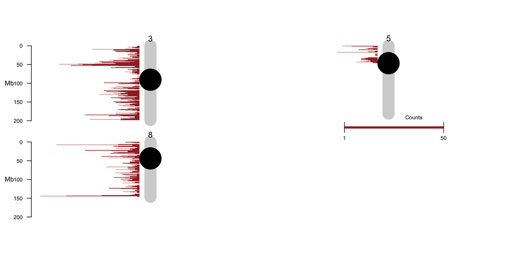

(#fig:all_in_genes)Queried genes. This plot shows these 1870 protein-coding genes chromosomal locations and density

```r
library(chromPlot)
data(hg_gap)
chromPlot(gaps=hg_gap, annot1 = gr, chr = c(3,5,8))
```

# 4 Running CiberAMP

CiberAMP will not use this mapping data. It is only necessary if we want to visualize our genes into the chromosomes as indicated in this example. We can skeep those steps if all we want is just running CiberAMP. This is the easiest thing ever: you only have to provide:

- A genes of interest character vector
- Those cohorts to be analyzed.
- The minimum % of copy number altered samples to be analyzed
- A path to a folder where results are going to be saved

```r
library(ciberAMP)
#x <- ciberAMP(genes = reg.genes$hgnc_symbol, cohorts = c("LUSC", "HNSC"), pat.percentage = 0, writePath = "/Users/lab02/Desktop/CiberAMP vignette folder")
x <- readRDS("/Users/lab02/Desktop/CiberAMP vignette folder/my_data.rds")
```

This is a computing expensive step, so we already provide you the results for the previous line. You can extract them easily.

```r
library(ciberAMP)
x <- readRDS("/Users/lab02/Desktop/CiberAMP vignette folder/my_data.rds")
```

In any case, if you have time to run it by yourself, we leave you here a description of all CiberAMP arguments for you notice:

- genes Your genes of interest official symbols. This should be a character vector.
- cohorts By default, CiberAMP will compute every TCGA cohort (the 32 available), but you can use this argument to only analyze a few. You can consult the offical codes at TCGA's web -> https://gdc.cancer.gov/resources-tcga-users/tcga-code-tables/tcga-study-abbreviations
- writePath The folder path to save the results. TIP: if you want to re-run CiberAMP, if you use the same folder where all data was stored, you will never need to re-download it again what saves a lot of time and disk space! But, be careful, every run your results will be overwritten!
- pat.percentage The minimum % of altered patients that should be considered to look for SCNA-driven differential expression. When in a cohort an event occurs recurrently it is more likely that such event may be under positive selection so being relevant for tumor fitness.
- pp.cor.cut Threshold to filter samples by AICC. Passed to `TCGAanalyze_Preprocessing`.
- norm.method Method of normalization, such as `gcContent` or `geneLength` (default).
- filt.method Method of filtering, such as `quantile` (default), `varFilter`, `filter1`, `filter2`.
- filt.qnt.cut Threshold selected as mean for filtering. Defaults to 0.25.
- filt.var.func Filtering function. Defaults to `IQR`. See `genefilter` documentation for available methods.
- filt.var.cutoff Threshold for `filt.var.funct`.
- filt.eta Parameter for `filter1`. Defaults to 0.05.
- filt.FDR.DEA Threshold to filter differentially expressed genes according their corrected p-value.
- filt.FC Parameter for `filter2`. Defaults to 1.
- p.val.thr Threshold for reported p values. Defaults to 1 (report all).
- cna.thr Threshold level for copy-number variation analysis. Can be `Deep`, `Shallow` or `Both`
- exp.mat Custom expression matrix, which will not be filtered. Defaults to `NULL`,
- cna.mat Custom copy-number analysis matrix, which will not be filtered. Defaults to `NULL`,

# 5 Looking into CiberAMP results

CiberAMP results into a list of 3 data frames that can be accessed by:

The x[[1]] data frame contains differential expression results for queried genes:

```r
head(x[[1]][1, ])
```

```
##   Gene_Symbol logFC logCPM PValue FDR Tumor log2FC.SCNAvsDip logCPM.SCNAvsDip
## 1       AADAC     0      0      1   1  LUSC         1.446066          7.04211
##   p.val.SCNAvsDip FDR.SCNAvsDip TCGA_Tumor                  Condition
## 1    3.848852e-14  1.968593e-13       LUSC Group AMP vs Group DIPLOID
##   Pat.percentage
## 1       27.71084
##                                                                                                                                                                                                                                                                                                          …
## 1 TCGA-18-3408,TCGA-18-3415,TCGA-18-3416,TCGA-18-4086,TCGA-18-5595,TCGA-21-1070,TCGA-21-1071,TCGA-21-1072,TCGA-21-1075,TCGA-21-1077,TCGA-21-1082,TCGA-21-5782,TCGA-22-4595,TCGA-22-4605,TCGA-22-4607,TCGA-22-4613,TCGA-22-5471,TCGA-22-5474,TCGA-22-5482,TCGA-33-4532,TCGA-33-4533,TCGA-33-4538,TCGA-33-4…
```

The x[[2]] data frame contains differential expression results for COSMIC cancer census genes list. Column information is exactly the same as x[[1]].

```r
head(x[[2]][1, ])
```

```
##    Gene_Symbol     logFC   logCPM        PValue          FDR Tumor
## 20        AFF3 -3.094773 5.455773 1.649102e-127 5.88691e-126  LUSC
##    log2FC.SCNAvsDip logCPM.SCNAvsDip p.val.SCNAvsDip FDR.SCNAvsDip TCGA_Tumor
## 20                0                0               1             1       LUSC
##                                          Condition Pat.percentage Pat.IDs
## 20 Not SCN-altered in more than 0 % of the samples              0    <NA>
```

Finally, the x[[3]] contains overlapping information between queried and CGC genes copy number overlap between samples. Genes may be CN-altered due to being lodged next to well-known and transcriptionally active in cancer cancer-related genes. In this data frame, you can consult if any of your queried CN-alterations would be highly correlated to any of known oncodrivers or tumor suppressors:

- Column 1 -> queried gene approved symbol.
- Column 2:5 -> queried gene copy number altered vs diploid tumor samples differential expression results.
- Column 6 -> TCGA cohort.
- Column 7 -> CN-altered vs diploid tumors comparison type: amplified vs diploid or deleted vs diploid.
- Column 8 -> % of samples CN-altered in queried gene.
- Column 9 -> CN-altered TCGA sample barcodes in queried gene.
- Column 10 -> COSMIC CGC gene approved symbol.
- Column 11:14 -> COSMIC CGC gene copy number altered vs diploid tumor samples differential expression results.
- Column 15 -> TCGA cohort.
- Column 16 -> CN-altered vs diploid tumors comparison type: amplified vs diploid or deleted vs diploid.
- Column 17 -> % of samples CN-altered in COSMIC CGC gene.
- Column 18 -> CN-altered TCGA sample barcodes in COSMIC CGC gene.
- Column 19 -> % of queried gene CN-altered samples that overlaps with COSMIC CGC gene CN-altered samples.
- Column 20 -> % of COSMIC CGC gene CN-altered samples that overlaps with queried gene CN-altered samples.

```r
head(x[[3]][1, ])
```

```
##      Gene_Symbol log2FC.SCNAvsDip logCPM.SCNAvsDip p.val.SCNAvsDip
## line       AADAC         1.446066          7.04211    3.848852e-14
##      FDR.SCNAvsDip TCGA_Tumor                  Condition Pat.percentage
## line  1.968593e-13       LUSC Group AMP vs Group DIPLOID       27.71084
##                                                                                                                                                                                                                                                                                                          …
## line TCGA-18-3408,TCGA-18-3415,TCGA-18-3416,TCGA-18-4086,TCGA-18-5595,TCGA-21-1070,TCGA-21-1071,TCGA-21-1072,TCGA-21-1075,TCGA-21-1077,TCGA-21-1082,TCGA-21-5782,TCGA-22-4595,TCGA-22-4605,TCGA-22-4607,TCGA-22-4613,TCGA-22-5471,TCGA-22-5474,TCGA-22-5482,TCGA-33-4532,TCGA-33-4533,TCGA-33-4538,TCGA-3…
##      Gene_Symbol_COSMIC log2FC.SCNAvsDip_COSMIC logCPM.SCNAvsDip_COSMIC
## line               MLF1                1.159256                8.541588
##      p.val.SCNAvsDip_COSMIC FDR.SCNAvsDip_COSMIC TCGA_Tumor_COSMIC
## line           3.045329e-10          7.66244e-10              LUSC
##                Condition_COSMIC Pat.percentage_COSMIC
## line Group AMP vs Group DIPLOID              30.12048
##                                                                                                                                                                                                                                                                                                          …
## line TCGA-18-3415,TCGA-18-3416,TCGA-18-4086,TCGA-18-5595,TCGA-21-1070,TCGA-21-1071,TCGA-21-1072,TCGA-21-1075,TCGA-21-1077,TCGA-21-1082,TCGA-21-5782,TCGA-22-4605,TCGA-22-4613,TCGA-22-5471,TCGA-22-5474,TCGA-22-5482,TCGA-33-4532,TCGA-33-4533,TCGA-33-4538,TCGA-33-4547,TCGA-33-4587,TCGA-33-A4WN,TCGA-3…
##      PROP_GENE_COSMIC PROP_COSMIC_GENE
## line         94.92754         87.33333
```

# 6 Mapping results into chromosomes

From the original 1870 genes we found that:

- 114 CN-altered queried genes show significant CN-driven differential expression in TCGA-HNSC cohort.
- 201 CN-altered queried genes show significant CN-driven differential expression in TCGA-LUSC cohort.
- Only 67 of them were found in both cohorts.

These are mapped in the next figure at their chromosomal positions:

```
## Chrom 3 : 198022430 bp
```

```
## Small segments, I will plot histograms for this track:
## Chrom 5 : 180915260 bp
```

```
## Small segments, I will plot histograms for this track:
## Chrom 8 : 146364022 bp
```

```
## Small segments, I will plot histograms for this track:
```

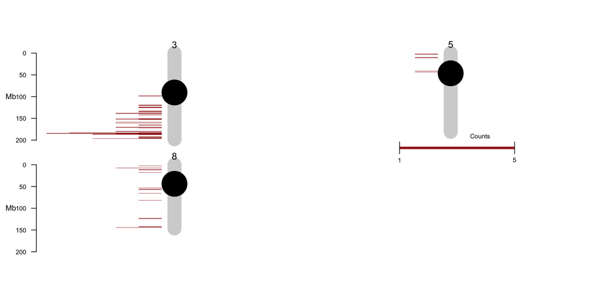

(#fig:only_assoc_both_genes)SCNA-driven differentially expressed genes.

```r
library(chromPlot)
df <- x[[1]]
genes_cosmic <- x[[3]]
gr.assoc.hnsc <- gr[gr$hgnc_symbol %in% as.character(df[df$Tumor %in% "HNSC" & abs(df$log2FC.SCNAvsDip) >= 1 & df$FDR.SCNAvsDip <= 0.01, ]$Gene_Symbol), ]
gr.assoc.lusc <- gr[gr$hgnc_symbol %in% as.character(df[df$Tumor %in% "LUSC" & abs(df$log2FC.SCNAvsDip) >= 1 & df$FDR.SCNAvsDip <= 0.01, ]$Gene_Symbol), ]
both <- intersect(gr.assoc.hnsc$hgnc_symbol, gr.assoc.lusc$hgnc_symbol)
chromPlot(gaps=hg_gap, annot1 = gr[gr$hgnc_symbol %in% both, ], chr = c(3,5,8))
```

The next question was: are these genes mapping very next to known COSMIC CGC ones? For that reason, we decided to graphically show it doing:

```
## Chrom 3 : 198022430 bp
```

```
## Small segments, I will plot histograms for this track:
## Small segments, I will plot histograms for this track:
## Chrom 5 : 180915260 bp
```

```
## Small segments, I will plot histograms for this track:
## Chrom 8 : 146364022 bp
```

```
## Small segments, I will plot histograms for this track:
## Small segments, I will plot histograms for this track:
```

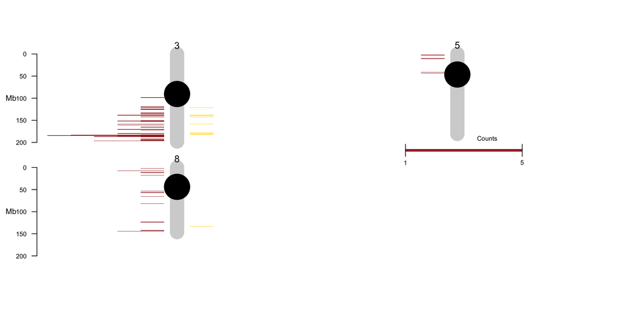

(#fig:genes_and_cosmic)SCNA-driven differentially expressed genes.

```r
library(chromPlot)
df.cosmic <- x[[2]]
gr.assoc.hnsc.cosmic <- gr[gr$hgnc_symbol %in% as.character(df.cosmic[df.cosmic$Tumor %in% "HNSC" & abs(df.cosmic$log2FC.SCNAvsDip) >= 1 & df.cosmic$FDR.SCNAvsDip <= 0.01, ]$Gene_Symbol), ]
gr.assoc.lusc.cosmic <- gr[gr$hgnc_symbol %in% as.character(df.cosmic[df.cosmic$Tumor %in% "LUSC" & abs(df.cosmic$log2FC.SCNAvsDip) >= 1 & df.cosmic$FDR.SCNAvsDip <= 0.01, ]$Gene_Symbol), ]
both.cosmic <- intersect(gr.assoc.hnsc.cosmic$hgnc_symbol, gr.assoc.lusc.cosmic$hgnc_symbol)
chromPlot(gaps=hg_gap, annot1 = gr[gr$hgnc_symbol %in% both, ], annot2 = gr[gr$hgnc_symbol %in% both.cosmic, ], chr = c(3,5,8), chrSide=c(-1,1,1,1,1,1,1,1))
```

# 7 GGplotting the results

CiberAMP package actually gives you a ggplot function to plot your results. This graph cosists in: 1) a X axis representing log2(FC) values for each genes comparing tumor and normal samples mRNA differential expression, and 2) a Y axis representing log2(FC) values for each gene comparing copy number altered vs diploid tumor samples mRNA differential expression. This plot will allow you to find out which or your genes are:

- Differentially expressed in tumor samples
- Differentially expressed in copy number altered samples.

And how these two data are connected:

- Upregulated genes which overexpression bursts due to copy number alteration -> x-value > 0; y-value > 0
- Upregualted genes exclusively when there is a copy alteration -> x-value = 0; y-value > 0
- Downregulated genes which copy number alteration increases very significantly its expression -> x-value < 0; y-value > 0
- Upregulated genes wich copy number alterations does not lead significant transcriptional alteration -> x-value != 0; y-value == 0
- Downregulated genes in tumors which copy number alteration even intensifies its repression -> x-value < 0; y-value < 0
- Downregulated genes exclusively repressed by copy number alteration -> x-value = 0, y-value < 0
- Upregualted genes which copy number alteration significantly represses its expression -> x-value > 0; y-value < 0

Here it is those 67 common CN-driven diff. expressed genes:

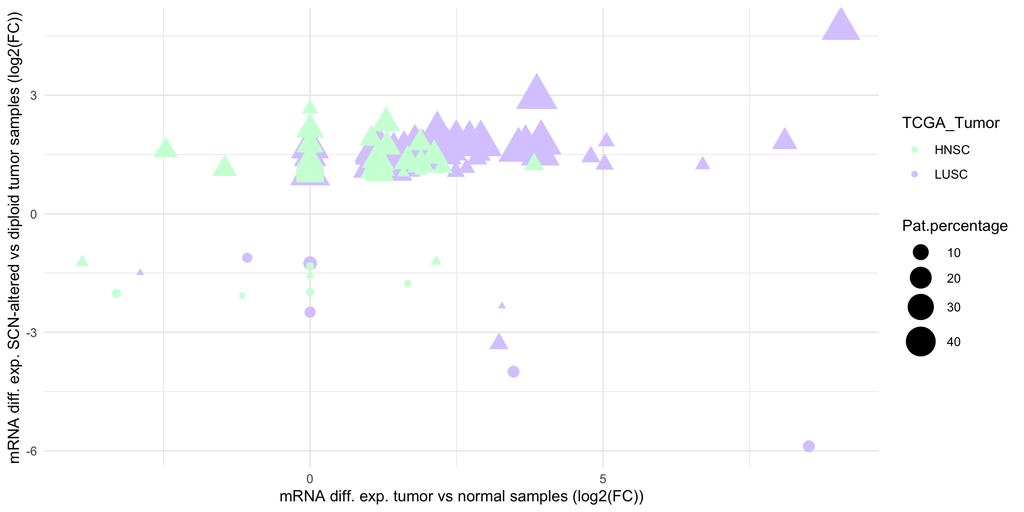

Figure 1: SCNA-driven differentially expressed genes

```r
library(ggplot2)
df.exp <- x[[1]]
df.exp <- df.exp[df.exp$Gene_Symbol %in% both, ]
ggplot.CiberAMP(df.exp)
```